# Tarea 4 Genomica funcional: REDES

Miguel Rodriguez

2025-04-11

## Preguntas Rapidas

**1. Considera una red de 15 nodos. Considera que tienes una sola conexión. ¿Cuál es el número máximo de nodos que puedes conectar? Dado un solo nodo , ¿cuál es el número máximo conexiones que puede tener tal nodo?**

El numero maximo de nodos que puedes conectar con una sola conexion son 2, ya que una conexion no direccionada o direccionada describe la interaccion o relacion entre 2 nodos, mientras que, dado un solo nodo este puede tener un maximo de 1 conexion si trabajamos con una conexion, pero su numero maximo de conexiones sin esta condicional sera el numero de nodos que pertenecen a la red y no son este mismo nodo, ya que, si solo consideramos las caracteristicas de una red normal, este puede conectarse con cualquier otro nodo, por lo que seria el numero maximo de nodos de la red -1.

**2. Considera una red dirigida de 10 nodos. Usa 25 conexiones y dibuja una red con ese número de nodos y conexiones dirigidas. Calcula la distribución de conectividades de salida.Calcula el número total de conexiones de salida ¿Cómo se compara el número total de de conectividades de entrada (son iguales, diferentes)? Explica tu respuesta. Calcula el promedio de entrada y de salida. Discute tu resultado.**

[figure not shown]

Red dirigida de 10 nodos y 25 conexiones

Posteriormente para calcular la distribucion de conexiones se utiliza la tabla anterior que tiene el numero de conexiones de entrada y salida para cada nodo, de tal forma que se estima por numero de conexion la frecuencia relativa (ej, para 3 conexiones de entrada hay una frecuencia de 3 de 10 nodos, por lo que su frecuencia relativa es 0.3)

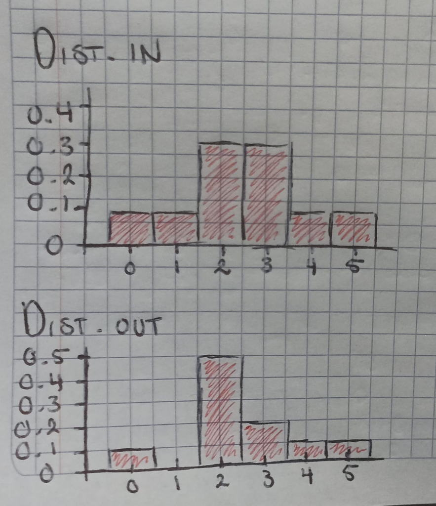

Visualizacion de distribuciones de conexiones de entrada y salida

El numero total de conectividad de entrada y salida es el mismo, esto debido a que las conexiones son las mismas, una conexion entre nodo A y B con direccion A hacia B tendra el mismo valor de entrada y salida, una conexion de entrada y una de salida, una conexion siempre representara una conexion de entrada y una de salida, por lo que la suma de las conexiones de entrada y salida siempre sera la misma, aun cuando la distribucion no es igual, esto debido a que es independiente que nodos se conectan entre ellos y cuales seran conexiones de entrada y de salida para cada nodo.

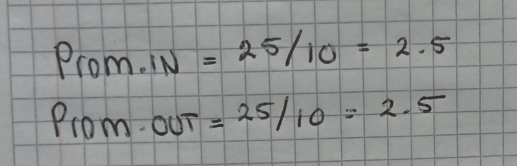

Promedio de conexiones

El promedio de conexiones es el mismo por la misma razon.

**3. Considera una red no dirigida de n = 3, 4, 5, 6 nodos respectivamente. ¿Cuál es el número máximo de conexiones que puedes poner? Dibuja cada caso. ¿Qué pasa si la red es dirigida?**

En general, en las redes no dirigidas la forma de estimar el numero maximo de conexiones es n(n-1)/2. Mientras que en las dirigidas es el doble de la estimacion anterior.

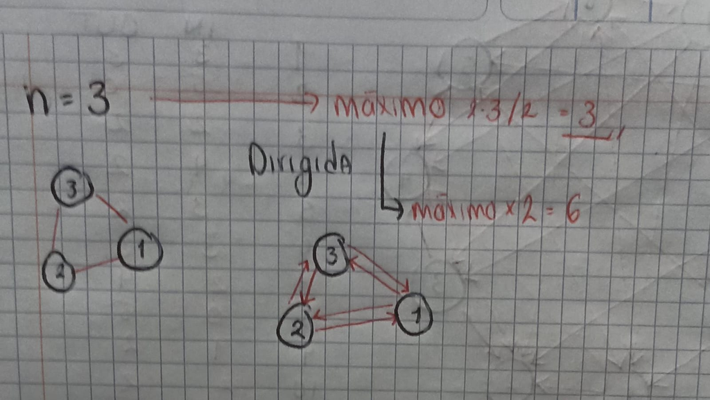

Red de N3 y la estimacion de su maximo de conexiones en no dirigidas y dirigidas

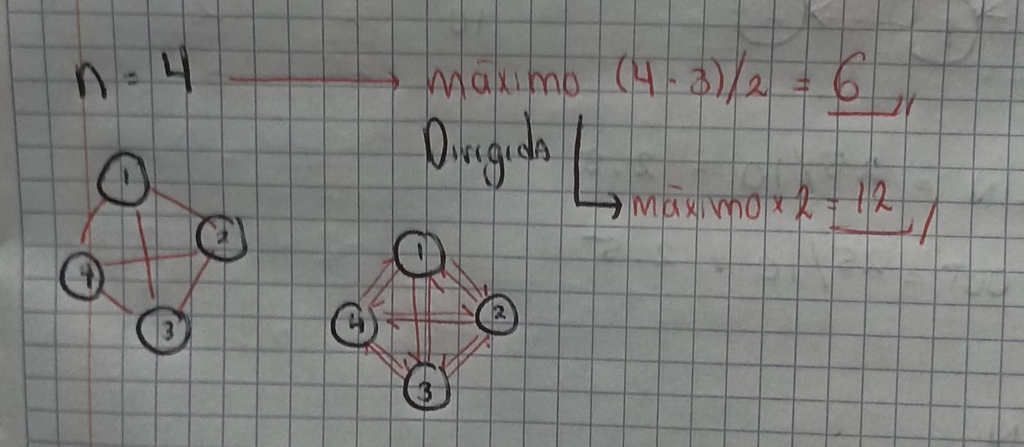

Red de N4 y la estimacion de su maximo de conexiones en no dirigidas y dirigidas

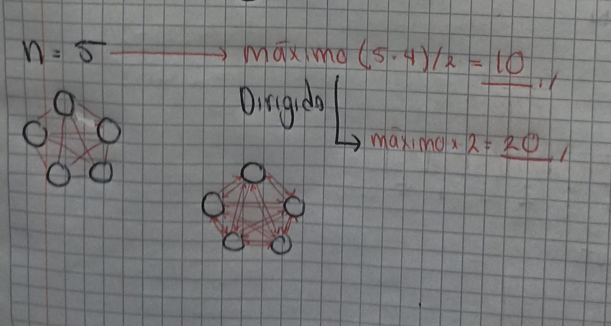

Red de N5 y la estimacion de su maximo de conexiones en no dirigidas y dirigidas

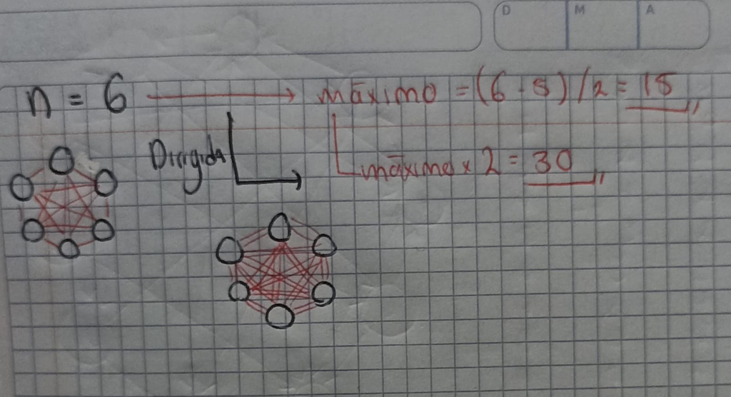

Red de N6 y la estimacion de su maximo de conexiones en no dirigidas y dirigidas

**4. Considera tu red de amigos reales.¿ Cuál es tu coeficiente de clusterización?**

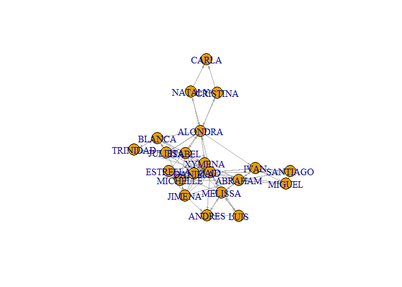

```r
g<-read.csv("../Data/adjacency_matrix.csv")
rownames(g)<-g[,1]
g<-g[,-1]
g<-as.matrix(g)
diag(g)<-0
red<-graph_from_adjacency_matrix(g)
plot(red,vertex.size=15,vertex.size=5,
     edge.arrow.size=0.25,layout=layout_nicely,vertex.size.label=0.25)
```

Tengo 3 amigos con conexion dirigida de entrada y salida, entonces como mis 3 amigos tienen el maximo numero de conexiones dirigidas: 6, entonces mi coeficiente de cluster es de 1.

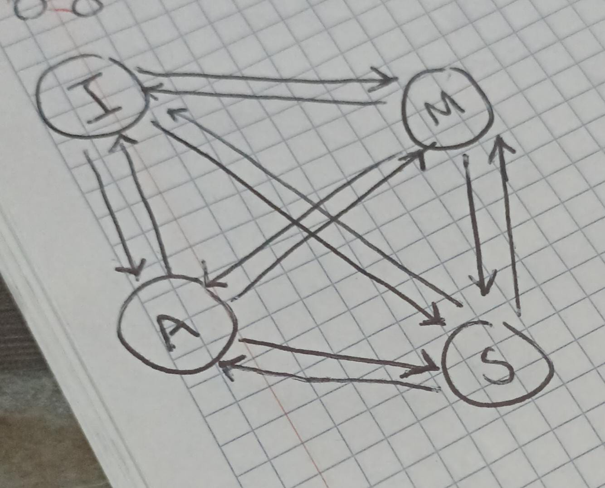

## Scripts, código, texto y gráficas

### 1. Propiedades básicas de redes

**red A**

• Número de conexiones = 9

• Número de nodos = 10

• Degree = 1:2, 2:3, 3:2, 4:3, 5:1, 6:3, 7:1, 8:1, 9:1, 10:1

• Average degree = 1.8

• Degree distribution = 0.5 para 1, 0.2 para 2, 0.3 para 3.

• Density = 0.18.

• Adjacency matrix

• Matriz de distancia

• Diámetro = 5

• Nodos más distantes = 5 y 9.

• Coeficiente de clusterización = 0.

**red B**

• Número de conexiones = 9

• Número de nodos = 10

• Degree = 1:5, 2:1, 3:1, 4:4, 5:1, 6:1, 7:1, 8:2, 9:1, 10:1

• Average degree = 1.8

• Degree distribution 0.7 para 1, 0.1 para 2, 0 para 3, 0.1 para 4 y 0.1 para 5.

• Density = 0.09

• Adjacency matrix

• Matriz de distancia

• Diámetro = 3

• Coeficiente de clusterización = 0

**red C**

• Número de conexiones = 45

• Número de nodos = 10

• Degree = 1:9, 2:9, 3:9, 4:9, 5:9, 6:9, 7:9, 8:9, 9:9, 10:9

• Average degree = 9

• Degree distribution = 1 para 9

• Density = 0.9

• Adjacency matrix

• Matriz de distancia

• Diámetro = 1

• Nodos más distantes = 1 y 2

• Coeficiente de clusterización = 1

**red D**

• Número de conexiones = 30

• Número de nodos = 10

• Degree = 1:6, 2:5, 3:5, 4:6, 5:5, 6:6, 7:4, 8:6, 9:7, 10:10

• Average degree = 6

• Degree distribution = 0.1 para 4, 0.3 para 5, 0.4 para 6, 0.1 para 7, 0.1 para 10

• Density = 0.3

• Adjacency matrix

• Matriz de distancia

• Diámetro = 3

• Nodos más distantes = 1 y 2

• Coeficiente de clusterización 0.637795

**red E**

• Número de conexiones = 13

• Número de nodos = 10

• Degree = 1:3, 2:1, 3:2, 4:2, 5:1, 6:2, 7:5, 8:4, 9:2, 10:4

• Average degree = 2.6

• Degree distribution = 0.2 para 1, 0.4 para 2, 0.1 para 3, 0.2 para 4 y 0.1 para 5

• Density = 0.26

• Adjacency matrix

• Matriz de distancia

• Diámetro = 4

• Nodos más distantes = 2 y 4

• Coeficiente de clusterización = 0.2068

**red F**

• Número de conexiones = 9

• Número de nodos = 10

• Degree = 1:2, 2:3, 3:3, 4:3, 5:2, 6:1, 7:1, 8:1, 9:1, 10:1

• Average degree = 1.8

• Degree distribution = 0.5 para 1, 0.2 para 2 y 0.3 para 3

• Density = 0.09

• Adjacency matrix

• Matriz de distancia

• Diámetro = 3

• Nodos más distantes = 1 y 8

• Coeficiente de clusterización = 0

Script en R para hacer las matrices

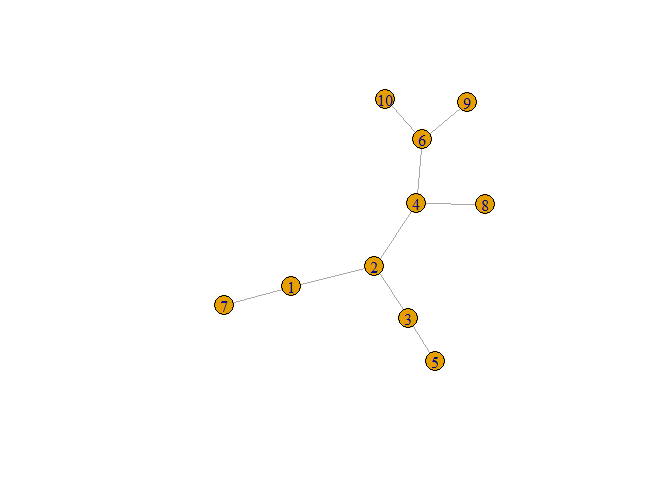

```r
## A

gA <- make_empty_graph(10, directed = FALSE)
gA <- add_edges(gA, c(1,2, 2,3, 2,4, 4,6, 6,9, 6,10, 4,8, 3,5, 1,7))
plot(gA)
```

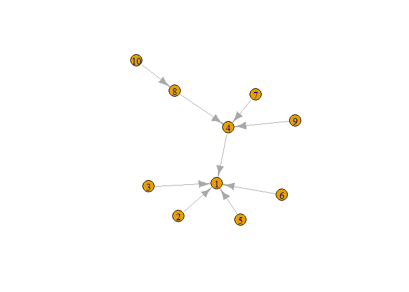

```r
## B

gB <- make_empty_graph(n = 10, directed = TRUE)
gB <- add_edges(gB, c(2,1,5,1,3,1,6,1,4,1,7,4,9,4,8,4,10,8))
plot(gB)
```

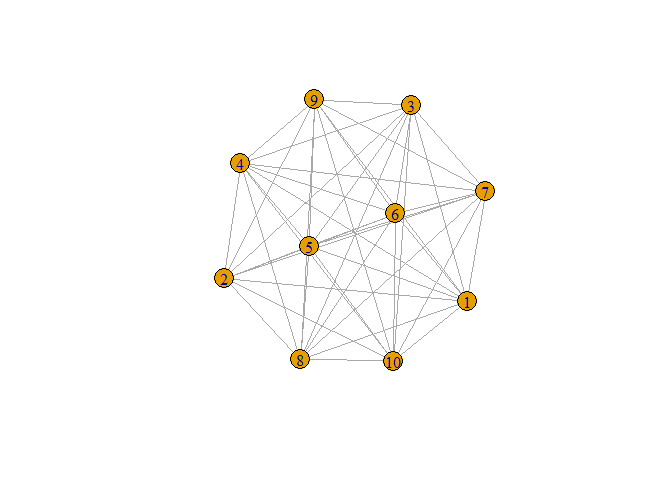

```r
## C

gC <- make_full_graph(10, directed = FALSE)
plot(gC)
```

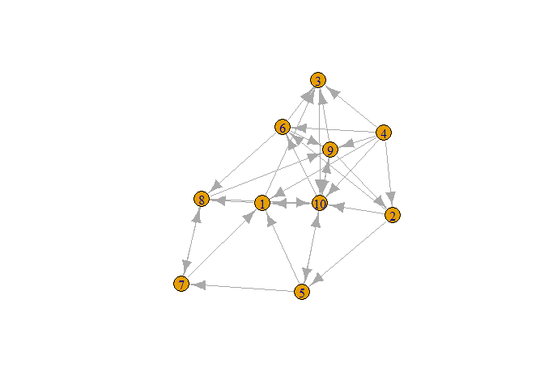

```r
## D

gD <- make_empty_graph(10, directed = TRUE)
gD <- add.edges(gD, c(4,3,9,3,1,3,6,3,2,6,10,6,4,6,6,8,7,8,1,8,8,7,5,7,7,1,5,1,10,1,4,1,10,5,2,5,4,2,9,2,4,10,2,10,5,10,8,10,9,10,3,10,4,9,10,9,8,9,6,9))
plot(gD)
```

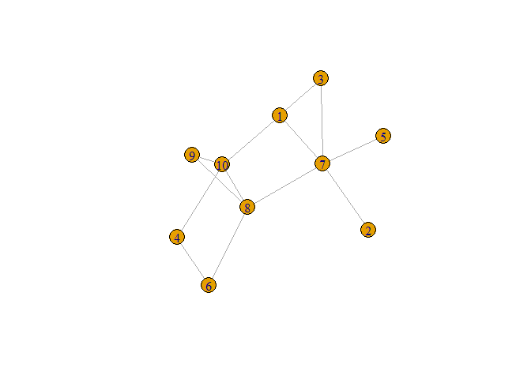

```r
## E

gE <- make_empty_graph(10, directed = FALSE)
gE <- add_edges(gE, c(5,7,2,7,3,7,1,3,7,1,8,7,1,10,8,9,8,10,8,6,10,4,6,4,9,10))
plot(gE)
```

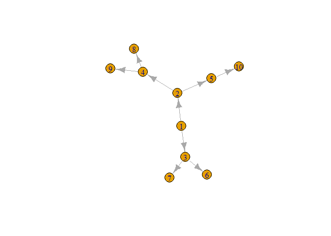

```r
## F

gF <- make_empty_graph(10, directed = TRUE)
gF <- add_edges(gF, c(4,8,4,9,2,4,2,5,5,10,1,2,1,3,3,6,3,7))
plot(gF)
```

```r
# Funcion para calculo de valores

Red_propiedades <- function(red, directed = FALSE){
  if(directed == FALSE){
    total <- (length(V(red))*(length(V(red)-1)))/2
  } else if(directed == TRUE){
    total <- ((length(V(red))*(length(V(red)-1)))/2)*2
  }
  x <- list()
for (i in 1:10) {
  x[i] <- shortest_paths(red, i)
}
dist <- c()
nombres <- c()
for (i in 1:10) {
  for (j in 1:10) {
    dist <- c(dist, length(x[[i]][[j]]))
    nombres <- c(nombres, paste(i, "y", j))
  }
}
dist
names(dist) <- nombres
dist

## Los nodos mas alejados entonces son:
sort(dist, decreasing = TRUE)[1]
  res <- list(
    No_conexiones = length(E(red)),
    No_nodos = length(V(red)),
    Degree = degree(red),
    Average_degree = mean(degree(red)),
    Degreee_distribution = degree.distribution(red),
    Densidad = length(E(red))/total,
    Matriz_adyacente = as.matrix(get.adjacency(red)),
    Matriz_distancia = distances(red),
    Diametro = diameter(red),
    Nodos_mas_lejanos = sort(dist, decreasing = TRUE)[1],
    Coeficiente_cluster = transitivity(red, type = "local")
  )
  return(res)
}

Red_propiedades(gA)
```

```
## $No_conexiones
## [1] 9
##
## $No_nodos
## [1] 10
##
## $Degree
##  [1] 2 3 2 3 1 3 1 1 1 1
##
## $Average_degree
## [1] 1.8
##
## $Degreee_distribution
## [1] 0.0 0.5 0.2 0.3
##
## $Densidad
## [1] 0.18
##
## $Matriz_adyacente
##       [,1] [,2] [,3] [,4] [,5] [,6] [,7] [,8] [,9] [,10]
##  [1,]    0    1    0    0    0    0    1    0    0     0
##  [2,]    1    0    1    1    0    0    0    0    0     0
##  [3,]    0    1    0    0    1    0    0    0    0     0
##  [4,]    0    1    0    0    0    1    0    1    0     0
##  [5,]    0    0    1    0    0    0    0    0    0     0
##  [6,]    0    0    0    1    0    0    0    0    1     1
##  [7,]    1    0    0    0    0    0    0    0    0     0
##  [8,]    0    0    0    1    0    0    0    0    0     0
##  [9,]    0    0    0    0    0    1    0    0    0     0
## [10,]    0    0    0    0    0    1    0    0    0     0
##
## $Matriz_distancia
##       [,1] [,2] [,3] [,4] [,5] [,6] [,7] [,8] [,9] [,10]
##  [1,]    0    1    2    2    3    3    1    3    4     4
##  [2,]    1    0    1    1    2    2    2    2    3     3
##  [3,]    2    1    0    2    1    3    3    3    4     4
##  [4,]    2    1    2    0    3    1    3    1    2     2
##  [5,]    3    2    1    3    0    4    4    4    5     5
##  [6,]    3    2    3    1    4    0    4    2    1     1
##  [7,]    1    2    3    3    4    4    0    4    5     5
##  [8,]    3    2    3    1    4    2    4    0    3     3
##  [9,]    4    3    4    2    5    1    5    3    0     2
## [10,]    4    3    4    2    5    1    5    3    2     0
##
## $Diametro
## [1] 5
##
## $Nodos_mas_lejanos
## 5 y 9
##     6
##
## $Coeficiente_cluster
##  [1]   0   0   0   0 NaN   0 NaN NaN NaN NaN
```

```r
Red_propiedades(gB, directed = TRUE)
```

```
## $No_conexiones
## [1] 9
##
## $No_nodos
## [1] 10
##
## $Degree
##  [1] 5 1 1 4 1 1 1 2 1 1
##
## $Average_degree
## [1] 1.8
##
## $Degreee_distribution
## [1] 0.0 0.7 0.1 0.0 0.1 0.1
##
## $Densidad
## [1] 0.09
##
## $Matriz_adyacente
##       [,1] [,2] [,3] [,4] [,5] [,6] [,7] [,8] [,9] [,10]
##  [1,]    0    0    0    0    0    0    0    0    0     0
##  [2,]    1    0    0    0    0    0    0    0    0     0
##  [3,]    1    0    0    0    0    0    0    0    0     0
##  [4,]    1    0    0    0    0    0    0    0    0     0
##  [5,]    1    0    0    0    0    0    0    0    0     0
##  [6,]    1    0    0    0    0    0    0    0    0     0
##  [7,]    0    0    0    1    0    0    0    0    0     0
##  [8,]    0    0    0    1    0    0    0    0    0     0
##  [9,]    0    0    0    1    0    0    0    0    0     0
## [10,]    0    0    0    0    0    0    0    1    0     0
##
## $Matriz_distancia
##       [,1] [,2] [,3] [,4] [,5] [,6] [,7] [,8] [,9] [,10]
##  [1,]    0    1    1    1    1    1    2    2    2     3
##  [2,]    1    0    2    2    2    2    3    3    3     4
##  [3,]    1    2    0    2    2    2    3    3    3     4
##  [4,]    1    2    2    0    2    2    1    1    1     2
##  [5,]    1    2    2    2    0    2    3    3    3     4
##  [6,]    1    2    2    2    2    0    3    3    3     4
##  [7,]    2    3    3    1    3    3    0    2    2     3
##  [8,]    2    3    3    1    3    3    2    0    2     1
##  [9,]    2    3    3    1    3    3    2    2    0     3
## [10,]    3    4    4    2    4    4    3    1    3     0
##
## $Diametro
## [1] 3
##
## $Nodos_mas_lejanos
## 10 y 1
##      4
##
## $Coeficiente_cluster
##  [1]   0 NaN NaN   0 NaN NaN NaN   0 NaN NaN
```

```r
Red_propiedades(gC)
```

```
## $No_conexiones
## [1] 45
##
## $No_nodos
## [1] 10
##
## $Degree
##  [1] 9 9 9 9 9 9 9 9 9 9
##
## $Average_degree
## [1] 9
##
## $Degreee_distribution
##  [1] 0 0 0 0 0 0 0 0 0 1
##
## $Densidad
## [1] 0.9
##
## $Matriz_adyacente
##       [,1] [,2] [,3] [,4] [,5] [,6] [,7] [,8] [,9] [,10]
##  [1,]    0    1    1    1    1    1    1    1    1     1
##  [2,]    1    0    1    1    1    1    1    1    1     1
##  [3,]    1    1    0    1    1    1    1    1    1     1
##  [4,]    1    1    1    0    1    1    1    1    1     1
##  [5,]    1    1    1    1    0    1    1    1    1     1
##  [6,]    1    1    1    1    1    0    1    1    1     1
##  [7,]    1    1    1    1    1    1    0    1    1     1
##  [8,]    1    1    1    1    1    1    1    0    1     1
##  [9,]    1    1    1    1    1    1    1    1    0     1
## [10,]    1    1    1    1    1    1    1    1    1     0
##
## $Matriz_distancia
##       [,1] [,2] [,3] [,4] [,5] [,6] [,7] [,8] [,9] [,10]
##  [1,]    0    1    1    1    1    1    1    1    1     1
##  [2,]    1    0    1    1    1    1    1    1    1     1
##  [3,]    1    1    0    1    1    1    1    1    1     1
##  [4,]    1    1    1    0    1    1    1    1    1     1
##  [5,]    1    1    1    1    0    1    1    1    1     1
##  [6,]    1    1    1    1    1    0    1    1    1     1
##  [7,]    1    1    1    1    1    1    0    1    1     1
##  [8,]    1    1    1    1    1    1    1    0    1     1
##  [9,]    1    1    1    1    1    1    1    1    0     1
## [10,]    1    1    1    1    1    1    1    1    1     0
##
## $Diametro
## [1] 1
##
## $Nodos_mas_lejanos
## 1 y 2
##     2
##
## $Coeficiente_cluster
##  [1] 1 1 1 1 1 1 1 1 1 1
```

```r
Red_propiedades(gD, directed = TRUE)
```

```
## $No_conexiones
## [1] 30
##
## $No_nodos
## [1] 10
##
## $Degree
##  [1]  6  5  5  6  5  6  4  6  7 10
##
## $Average_degree
## [1] 6
##
## $Degreee_distribution
##  [1] 0.0 0.0 0.0 0.0 0.1 0.3 0.4 0.1 0.0 0.0 0.1
##
## $Densidad
## [1] 0.3
##
## $Matriz_adyacente
##       [,1] [,2] [,3] [,4] [,5] [,6] [,7] [,8] [,9] [,10]
##  [1,]    0    0    1    0    0    0    0    1    0     0
##  [2,]    0    0    0    0    1    1    0    0    0     1
##  [3,]    0    0    0    0    0    0    0    0    0     1
##  [4,]    1    1    1    0    0    1    0    0    1     1
##  [5,]    1    0    0    0    0    0    1    0    0     1
##  [6,]    0    0    1    0    0    0    0    1    1     0
##  [7,]    1    0    0    0    0    0    0    1    0     0
##  [8,]    0    0    0    0    0    0    1    0    1     1
##  [9,]    0    1    1    0    0    0    0    0    0     1
## [10,]    1    0    0    0    1    1    0    0    1     0
##
## $Matriz_distancia
##       [,1] [,2] [,3] [,4] [,5] [,6] [,7] [,8] [,9] [,10]
##  [1,]    0    2    1    1    1    2    1    1    2     1
##  [2,]    2    0    2    1    1    1    2    2    1     1
##  [3,]    1    2    0    1    2    1    2    2    1     1
##  [4,]    1    1    1    0    2    1    2    2    1     1
##  [5,]    1    1    2    2    0    2    1    2    2     1
##  [6,]    2    1    1    1    2    0    2    1    1     1
##  [7,]    1    2    2    2    1    2    0    1    2     2
##  [8,]    1    2    2    2    2    1    1    0    1     1
##  [9,]    2    1    1    1    2    1    2    1    0     1
## [10,]    1    1    1    1    1    1    2    1    1     0
##
## $Diametro
## [1] 3
##
## $Nodos_mas_lejanos
## 1 y 2
##     4
##
## $Coeficiente_cluster
##  [1] 0.4666667 0.7000000 0.8000000 0.7333333 0.5000000 0.7333333 0.6666667
##  [8] 0.5000000 0.7333333 0.5714286
```

```r
Red_propiedades(gE)
```

```
## $No_conexiones
## [1] 13
##
## $No_nodos
## [1] 10
##
## $Degree
##  [1] 3 1 2 2 1 2 5 4 2 4
##
## $Average_degree
## [1] 2.6
##
## $Degreee_distribution
## [1] 0.0 0.2 0.4 0.1 0.2 0.1
##
## $Densidad
## [1] 0.26
##
## $Matriz_adyacente
##       [,1] [,2] [,3] [,4] [,5] [,6] [,7] [,8] [,9] [,10]
##  [1,]    0    0    1    0    0    0    1    0    0     1
##  [2,]    0    0    0    0    0    0    1    0    0     0
##  [3,]    1    0    0    0    0    0    1    0    0     0
##  [4,]    0    0    0    0    0    1    0    0    0     1
##  [5,]    0    0    0    0    0    0    1    0    0     0
##  [6,]    0    0    0    1    0    0    0    1    0     0
##  [7,]    1    1    1    0    1    0    0    1    0     0
##  [8,]    0    0    0    0    0    1    1    0    1     1
##  [9,]    0    0    0    0    0    0    0    1    0     1
## [10,]    1    0    0    1    0    0    0    1    1     0
##
## $Matriz_distancia
##       [,1] [,2] [,3] [,4] [,5] [,6] [,7] [,8] [,9] [,10]
##  [1,]    0    2    1    2    2    3    1    2    2     1
##  [2,]    2    0    2    4    2    3    1    2    3     3
##  [3,]    1    2    0    3    2    3    1    2    3     2
##  [4,]    2    4    3    0    4    1    3    2    2     1
##  [5,]    2    2    2    4    0    3    1    2    3     3
##  [6,]    3    3    3    1    3    0    2    1    2     2
##  [7,]    1    1    1    3    1    2    0    1    2     2
##  [8,]    2    2    2    2    2    1    1    0    1     1
##  [9,]    2    3    3    2    3    2    2    1    0     1
## [10,]    1    3    2    1    3    2    2    1    1     0
##
## $Diametro
## [1] 4
##
## $Nodos_mas_lejanos
## 2 y 4
##     5
##
## $Coeficiente_cluster
##  [1] 0.3333333       NaN 1.0000000 0.0000000       NaN 0.0000000 0.1000000
##  [8] 0.1666667 1.0000000 0.1666667
```

```r
Red_propiedades(gF, directed = TRUE)
```

```
## $No_conexiones
## [1] 9
##
## $No_nodos
## [1] 10
##
## $Degree
##  [1] 2 3 3 3 2 1 1 1 1 1
##
## $Average_degree
## [1] 1.8
##
## $Degreee_distribution
## [1] 0.0 0.5 0.2 0.3
##
## $Densidad
## [1] 0.09
##
## $Matriz_adyacente
##       [,1] [,2] [,3] [,4] [,5] [,6] [,7] [,8] [,9] [,10]
##  [1,]    0    1    1    0    0    0    0    0    0     0
##  [2,]    0    0    0    1    1    0    0    0    0     0
##  [3,]    0    0    0    0    0    1    1    0    0     0
##  [4,]    0    0    0    0    0    0    0    1    1     0
##  [5,]    0    0    0    0    0    0    0    0    0     1
##  [6,]    0    0    0    0    0    0    0    0    0     0
##  [7,]    0    0    0    0    0    0    0    0    0     0
##  [8,]    0    0    0    0    0    0    0    0    0     0
##  [9,]    0    0    0    0    0    0    0    0    0     0
## [10,]    0    0    0    0    0    0    0    0    0     0
##
## $Matriz_distancia
##       [,1] [,2] [,3] [,4] [,5] [,6] [,7] [,8] [,9] [,10]
##  [1,]    0    1    1    2    2    2    2    3    3     3
##  [2,]    1    0    2    1    1    3    3    2    2     2
##  [3,]    1    2    0    3    3    1    1    4    4     4
##  [4,]    2    1    3    0    2    4    4    1    1     3
##  [5,]    2    1    3    2    0    4    4    3    3     1
##  [6,]    2    3    1    4    4    0    2    5    5     5
##  [7,]    2    3    1    4    4    2    0    5    5     5
##  [8,]    3    2    4    1    3    5    5    0    2     4
##  [9,]    3    2    4    1    3    5    5    2    0     4
## [10,]    3    2    4    3    1    5    5    4    4     0
##
## $Diametro
## [1] 3
##
## $Nodos_mas_lejanos
## 1 y 8
##     4
##
## $Coeficiente_cluster
##  [1]   0   0   0   0   0 NaN NaN NaN NaN NaN
```

### 2. Karate

```r
karate <- make_graph("Zachary")
karate
```

```
## IGRAPH eaa9d05 U--- 34 78 -- Zachary
## + attr: name (g/c)
## + edges from eaa9d05:
##  [1]  1-- 2  1-- 3  1-- 4  1-- 5  1-- 6  1-- 7  1-- 8  1-- 9  1--11  1--12
## [11]  1--13  1--14  1--18  1--20  1--22  1--32  2-- 3  2-- 4  2-- 8  2--14
## [21]  2--18  2--20  2--22  2--31  3-- 4  3-- 8  3--28  3--29  3--33  3--10
## [31]  3-- 9  3--14  4-- 8  4--13  4--14  5-- 7  5--11  6-- 7  6--11  6--17
## [41]  7--17  9--31  9--33  9--34 10--34 14--34 15--33 15--34 16--33 16--34
## [51] 19--33 19--34 20--34 21--33 21--34 23--33 23--34 24--26 24--28 24--33
## [61] 24--34 24--30 25--26 25--28 25--32 26--32 27--30 27--34 28--34 29--32
## [71] 29--34 30--33 30--34 31--33 31--34 32--33 32--34 33--34
```

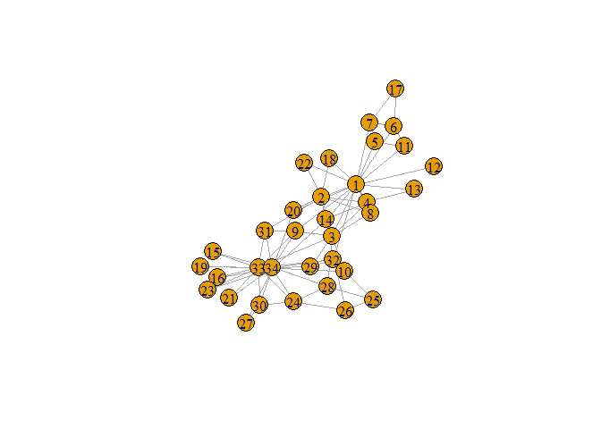

```r
plot(karate)
```

• ¿Cuántos nodos y conexiones tiene?

Tiene 78 conexiones y 34 nodos.

• ¿Quiénes son los nodos y cuál es la regla de conexión?

Los nodos son estudiantes del club de karate de Zachary, mientras que los nodos se conectan segun si hay interaccion afuera del club entre los estudiantes.

• ¿Qué tan densa es la red?

• ¿Cómo obtienes la matriz de adyacencia?

La matriz de adyacencia se obtiene representando las conexiones con numeros (1) y la falta de conexion entre nodos con (0).

```r
Red_propiedades(karate)$Matriz_adyacente
```

```
##       [,1] [,2] [,3] [,4] [,5] [,6] [,7] [,8] [,9] [,10] [,11] [,12] [,13]
##  [1,]    0    1    1    1    1    1    1    1    1     0     1     1     1
##  [2,]    1    0    1    1    0    0    0    1    0     0     0     0     0
##  [3,]    1    1    0    1    0    0    0    1    1     1     0     0     0
##  [4,]    1    1    1    0    0    0    0    1    0     0     0     0     1
##  [5,]    1    0    0    0    0    0    1    0    0     0     1     0     0
##  [6,]    1    0    0    0    0    0    1    0    0     0     1     0     0
##  [7,]    1    0    0    0    1    1    0    0    0     0     0     0     0
##  [8,]    1    1    1    1    0    0    0    0    0     0     0     0     0
##  [9,]    1    0    1    0    0    0    0    0    0     0     0     0     0
## [10,]    0    0    1    0    0    0    0    0    0     0     0     0     0
## [11,]    1    0    0    0    1    1    0    0    0     0     0     0     0
## [12,]    1    0    0    0    0    0    0    0    0     0     0     0     0
## [13,]    1    0    0    1    0    0    0    0    0     0     0     0     0
## [14,]    1    1    1    1    0    0    0    0    0     0     0     0     0
```

[output cut: 90 more lines]

• ¿Es una red dirigida, pesada?

Es una red no dirigida y sin peso.

• Calcula y gráfica la distribución de conectividades

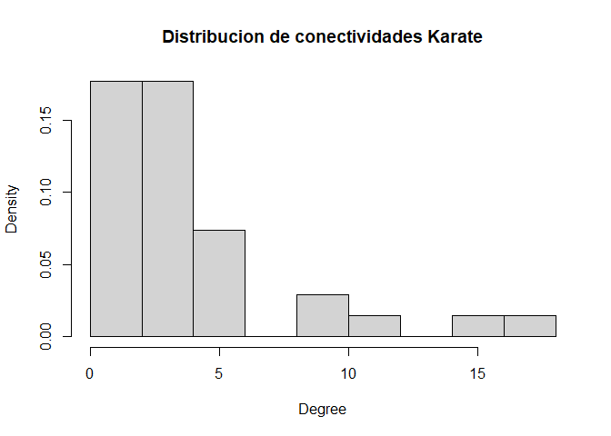

```r
hist(sort(Red_propiedades(karate)$Degree), probability = TRUE, main = "Distribucion de conectividades Karate", xlab = "Degree")
```

• Calcula el diámetro, la matriz de distancias y la distancia promedio

```r
# Diametro

Red_propiedades(karate)$Diametro
```

```
## [1] 5
```

```r
# Matriz de distancias

Red_propiedades(karate)$Matriz_distancia
```

```
##       [,1] [,2] [,3] [,4] [,5] [,6] [,7] [,8] [,9] [,10] [,11] [,12] [,13]
##  [1,]    0    1    1    1    1    1    1    1    1     2     1     1     1
##  [2,]    1    0    1    1    2    2    2    1    2     2     2     2     2
##  [3,]    1    1    0    1    2    2    2    1    1     1     2     2     2
##  [4,]    1    1    1    0    2    2    2    1    2     2     2     2     1
##  [5,]    1    2    2    2    0    2    1    2    2     3     1     2     2
##  [6,]    1    2    2    2    2    0    1    2    2     3     1     2     2
##  [7,]    1    2    2    2    1    1    0    2    2     3     2     2     2
##  [8,]    1    1    1    1    2    2    2    0    2     2     2     2     2
##  [9,]    1    2    1    2    2    2    2    2    0     2     2     2     2
## [10,]    2    2    1    2    3    3    3    2    2     0     3     3     3
## [11,]    1    2    2    2    1    1    2    2    2     3     0     2     2
## [12,]    1    2    2    2    2    2    2    2    2     3     2     0     2
## [13,]    1    2    2    1    2    2    2    2    2     3     2     2     0
## [14,]    1    1    1    1    2    2    2    2    2     2     2     2     2
```

[output cut: 90 more lines]

```r
# Promedio de distancias

mean(Red_propiedades(karate)$Matriz_distancia)
```

```
## [1] 2.33737
```

• Encuentra la trayectoria de los nodos más alejados.

```r
sort(Red_propiedades(karate)$Matriz_distancia, decreasing = TRUE)[1:20]
```

```
##  [1] 5 5 5 5 5 5 5 5 5 5 5 5 5 5 5 5 4 4 4 4
```

```r
## Hay 16 nodos con distancia de 5 como maximo.

mat <- Red_propiedades(karate)$Matriz_distancia

row.names(mat) <- colnames(mat) <- c(1:34)

dist5 <- which(mat == 5, arr.ind = TRUE)
dist5
```

```
##    row col
## 17  17  15
## 17  17  16
## 15  15  17
## 16  16  17
## 19  19  17
## 21  21  17
## 23  23  17
## 24  24  17
## 27  27  17
## 30  30  17
## 17  17  19
## 17  17  21
## 17  17  23
## 17  17  24
## 17  17  27
## 17  17  30
```

```r
# Ahora tenemos que eliminar aquellos pares duplicados, se va a hacer con un ciclo for anidado.

x <- 0
for(i in 1:16){
  for (j in i:16) {
    if(dist5[i,][1] == dist5[j,][2] & dist5[i,][2] == dist5[j,][1]){
      x <- c(x, j)
    }
  }
}
x
```

```
## [1]  0  3  4 11 12 13 14 15 16
```

```r
dist5 <- dist5[-c(x),]

# Finalmente extraemos los row y col names para saber que nodos son
pares_dist_5 <- data.frame(
  Nodo_1 = rownames(mat)[dist5[, 1]],
  Nodo_2 = colnames(mat)[dist5[, 2]],
  distancia = mat[dist5]
)

pares_dist_5
```

```
##   Nodo_1 Nodo_2 distancia
## 1     17     15         5
## 2     17     16         5
## 3     19     17         5
## 4     21     17         5
## 5     23     17         5
## 6     24     17         5
## 7     27     17         5
## 8     30     17         5
```

• Existen nodos con coefeiciente de clusterización 1. ¿Qué significa?

Significa que los nodos a los que ellos estan conectados tienen el maximo de conexiones posibles entre ellos, ej. un nodo con conexion a 3 nodos tienen 3 conexiones entre ellos, el cual es el numero maximo de conexiones. En el contexto de esta red significa que los estudiantes con los que interactua el individuo A interactuan a su vez entre ellos.

• Mide , con al menos tres medidas de centralidad, los nodos más importantes.

Primero centralidad de grado.

```r
degree(karate, V(karate)[1])
```

```
## [1] 16
```

```r
degree(karate, V(karate)[34])
```

```
## [1] 17
```

Posteriormente el betweenness que mide cuantas veces un nodo actua como un puente a lo largo del camino mas corto de otros nodos.

```r
betweenness(karate, V(karate)[1])
```

```
## [1] 231.0714
```

```r
betweenness(karate, V(karate)[34])
```

```
## [1] 160.5516
```

Y finalmente la centralidad de proximidad, que mide cuan cerca esta un nodo de los otros nodos de la red.

```r
closeness(karate, V(karate)[1])
```

```
## [1] 0.01724138
```

```r
closeness(karate, V(karate)[34])
```

```
## [1] 0.01666667
```